# Risk Factor Analysis

## Outcome Variable

**Outcome Variable:** sstunted

## Predictor Variables

**Intervention Variable:** exclfeed36

**Adjustment Set:**

unadjusted

## Stratifying Variables

The analysis was stratified on these variable(s):

- agecat
- studyid
- country

## Data Summary

| agecat | studyid | country | exclfeed36 | sstunted | n_cell | n |
| --- | --- | --- | --- | --- | --- | --- |
| Birth | ki0047075b-MAL-ED | BANGLADESH | 0 | 0 | 175 | 243 |
| Birth | ki0047075b-MAL-ED | BANGLADESH | 0 | 1 | 6 | 243 |
| Birth | ki0047075b-MAL-ED | BANGLADESH | 1 | 0 | 61 | 243 |
| Birth | ki0047075b-MAL-ED | BANGLADESH | 1 | 1 | 1 | 243 |
| Birth | ki0047075b-MAL-ED | BRAZIL | 0 | 0 | 165 | 185 |
| Birth | ki0047075b-MAL-ED | BRAZIL | 0 | 1 | 7 | 185 |
| Birth | ki0047075b-MAL-ED | BRAZIL | 1 | 0 | 12 | 185 |
| Birth | ki0047075b-MAL-ED | BRAZIL | 1 | 1 | 1 | 185 |
| Birth | ki0047075b-MAL-ED | INDIA | 0 | 0 | 186 | 198 |
| Birth | ki0047075b-MAL-ED | INDIA | 0 | 1 | 7 | 198 |
| Birth | ki0047075b-MAL-ED | INDIA | 1 | 0 | 5 | 198 |
| Birth | ki0047075b-MAL-ED | INDIA | 1 | 1 | 0 | 198 |
| Birth | ki0047075b-MAL-ED | NEPAL | 0 | 0 | 155 | 172 |
| Birth | ki0047075b-MAL-ED | NEPAL | 0 | 1 | 6 | 172 |
| Birth | ki0047075b-MAL-ED | NEPAL | 1 | 0 | 11 | 172 |
| Birth | ki0047075b-MAL-ED | NEPAL | 1 | 1 | 0 | 172 |
| Birth | ki0047075b-MAL-ED | PERU | 0 | 0 | 253 | 273 |
| Birth | ki0047075b-MAL-ED | PERU | 0 | 1 | 5 | 273 |
| Birth | ki0047075b-MAL-ED | PERU | 1 | 0 | 14 | 273 |
| Birth | ki0047075b-MAL-ED | PERU | 1 | 1 | 1 | 273 |
| Birth | ki0047075b-MAL-ED | SOUTH AFRICA | 0 | 0 | 235 | 236 |
| Birth | ki0047075b-MAL-ED | SOUTH AFRICA | 0 | 1 | 1 | 236 |
| Birth | ki0047075b-MAL-ED | SOUTH AFRICA | 1 | 0 | 0 | 236 |
| Birth | ki0047075b-MAL-ED | SOUTH AFRICA | 1 | 1 | 0 | 236 |
| Birth | ki0047075b-MAL-ED | TANZANIA, UNITED REPUBLIC OF | 0 | 0 | 114 | 121 |
| Birth | ki0047075b-MAL-ED | TANZANIA, UNITED REPUBLIC OF | 0 | 1 | 6 | 121 |
| Birth | ki0047075b-MAL-ED | TANZANIA, UNITED REPUBLIC OF | 1 | 0 | 1 | 121 |
| Birth | ki0047075b-MAL-ED | TANZANIA, UNITED REPUBLIC OF | 1 | 1 | 0 | 121 |
| Birth | ki1000108-CMC-V-BCS-2002 | INDIA | 0 | 0 | 0 | 3 |
| Birth | ki1000108-CMC-V-BCS-2002 | INDIA | 0 | 1 | 0 | 3 |

[output cut: 150 more lines]

The following strata were considered:

- agecat: 24 months, studyid: ki0047075b-MAL-ED, country: BANGLADESH
- agecat: 24 months, studyid: ki0047075b-MAL-ED, country: BRAZIL
- agecat: 24 months, studyid: ki0047075b-MAL-ED, country: INDIA
- agecat: 24 months, studyid: ki0047075b-MAL-ED, country: NEPAL
- agecat: 24 months, studyid: ki0047075b-MAL-ED, country: PERU
- agecat: 24 months, studyid: ki0047075b-MAL-ED, country: SOUTH AFRICA
- agecat: 24 months, studyid: ki0047075b-MAL-ED, country: TANZANIA, UNITED REPUBLIC OF
- agecat: 24 months, studyid: ki1000108-CMC-V-BCS-2002, country: INDIA
- agecat: 24 months, studyid: ki1000108-IRC, country: INDIA
- agecat: 24 months, studyid: ki1017093b-PROVIDE, country: BANGLADESH
- agecat: 24 months, studyid: ki1101329-Keneba, country: GAMBIA
- agecat: 24 months, studyid: ki1113344-GMS-Nepal, country: NEPAL
- agecat: 24 months, studyid: ki1148112-LCNI-5, country: MALAWI
- agecat: 24 months, studyid: kiGH5241-JiVitA-3, country: BANGLADESH
- agecat: 24 months, studyid: kiGH5241-JiVitA-4, country: BANGLADESH
- agecat: 6 months, studyid: ki0047075b-MAL-ED, country: BANGLADESH
- agecat: 6 months, studyid: ki0047075b-MAL-ED, country: BRAZIL
- agecat: 6 months, studyid: ki0047075b-MAL-ED, country: INDIA
- agecat: 6 months, studyid: ki0047075b-MAL-ED, country: NEPAL
- agecat: 6 months, studyid: ki0047075b-MAL-ED, country: PERU
- agecat: 6 months, studyid: ki0047075b-MAL-ED, country: SOUTH AFRICA
- agecat: 6 months, studyid: ki0047075b-MAL-ED, country: TANZANIA, UNITED REPUBLIC OF
- agecat: 6 months, studyid: ki1000108-CMC-V-BCS-2002, country: INDIA
- agecat: 6 months, studyid: ki1000108-IRC, country: INDIA
- agecat: 6 months, studyid: ki1000109-EE, country: PAKISTAN
- agecat: 6 months, studyid: ki1000304b-SAS-FoodSuppl, country: INDIA
- agecat: 6 months, studyid: ki1017093b-PROVIDE, country: BANGLADESH
- agecat: 6 months, studyid: ki1101329-Keneba, country: GAMBIA
- agecat: 6 months, studyid: ki1113344-GMS-Nepal, country: NEPAL
- agecat: 6 months, studyid: ki1148112-LCNI-5, country: MALAWI
- agecat: 6 months, studyid: kiGH5241-JiVitA-3, country: BANGLADESH
- agecat: 6 months, studyid: kiGH5241-JiVitA-4, country: BANGLADESH
- agecat: Birth, studyid: ki0047075b-MAL-ED, country: BANGLADESH
- agecat: Birth, studyid: ki0047075b-MAL-ED, country: BRAZIL
- agecat: Birth, studyid: ki0047075b-MAL-ED, country: INDIA
- agecat: Birth, studyid: ki0047075b-MAL-ED, country: NEPAL
- agecat: Birth, studyid: ki0047075b-MAL-ED, country: PERU
- agecat: Birth, studyid: ki0047075b-MAL-ED, country: SOUTH AFRICA
- agecat: Birth, studyid: ki0047075b-MAL-ED, country: TANZANIA, UNITED REPUBLIC OF
- agecat: Birth, studyid: ki1000108-CMC-V-BCS-2002, country: INDIA
- agecat: Birth, studyid: ki1000108-IRC, country: INDIA
- agecat: Birth, studyid: ki1000109-EE, country: PAKISTAN
- agecat: Birth, studyid: ki1101329-Keneba, country: GAMBIA
- agecat: Birth, studyid: kiGH5241-JiVitA-3, country: BANGLADESH
- agecat: Birth, studyid: kiGH5241-JiVitA-4, country: BANGLADESH

### Dropped Strata

Some strata were dropped due to rare outcomes:

- agecat: Birth, studyid: ki0047075b-MAL-ED, country: BANGLADESH
- agecat: Birth, studyid: ki0047075b-MAL-ED, country: BRAZIL
- agecat: Birth, studyid: ki0047075b-MAL-ED, country: INDIA
- agecat: Birth, studyid: ki0047075b-MAL-ED, country: NEPAL
- agecat: Birth, studyid: ki0047075b-MAL-ED, country: PERU
- agecat: Birth, studyid: ki0047075b-MAL-ED, country: SOUTH AFRICA
- agecat: Birth, studyid: ki0047075b-MAL-ED, country: TANZANIA, UNITED REPUBLIC OF
- agecat: Birth, studyid: ki1000108-CMC-V-BCS-2002, country: INDIA
- agecat: Birth, studyid: ki1000108-IRC, country: INDIA
- agecat: Birth, studyid: ki1000109-EE, country: PAKISTAN
- agecat: 6 months, studyid: ki0047075b-MAL-ED, country: BANGLADESH
- agecat: 6 months, studyid: ki0047075b-MAL-ED, country: BRAZIL
- agecat: 6 months, studyid: ki0047075b-MAL-ED, country: INDIA
- agecat: 6 months, studyid: ki0047075b-MAL-ED, country: NEPAL
- agecat: 6 months, studyid: ki0047075b-MAL-ED, country: PERU
- agecat: 6 months, studyid: ki0047075b-MAL-ED, country: SOUTH AFRICA
- agecat: 6 months, studyid: ki0047075b-MAL-ED, country: TANZANIA, UNITED REPUBLIC OF
- agecat: 6 months, studyid: ki1000108-CMC-V-BCS-2002, country: INDIA
- agecat: 6 months, studyid: ki1000108-IRC, country: INDIA
- agecat: 6 months, studyid: ki1000304b-SAS-FoodSuppl, country: INDIA
- agecat: 6 months, studyid: ki1017093b-PROVIDE, country: BANGLADESH
- agecat: 6 months, studyid: ki1148112-LCNI-5, country: MALAWI
- agecat: 24 months, studyid: ki0047075b-MAL-ED, country: BRAZIL
- agecat: 24 months, studyid: ki0047075b-MAL-ED, country: INDIA
- agecat: 24 months, studyid: ki0047075b-MAL-ED, country: NEPAL
- agecat: 24 months, studyid: ki0047075b-MAL-ED, country: PERU
- agecat: 24 months, studyid: ki0047075b-MAL-ED, country: SOUTH AFRICA
- agecat: 24 months, studyid: ki0047075b-MAL-ED, country: TANZANIA, UNITED REPUBLIC OF
- agecat: 24 months, studyid: ki1000108-CMC-V-BCS-2002, country: INDIA
- agecat: 24 months, studyid: ki1000108-IRC, country: INDIA
- agecat: 24 months, studyid: ki1148112-LCNI-5, country: MALAWI

## Methods Detail

We’re interested in the causal parameters $E[Y_a]$ for all values of $a \in \mathcal{A}$. These parameters represent the mean outcome if, possibly contrary to fact, we intervened to set all units to have $A=a$. Under the randomization and positivity assumptions, these are identified by the statistical parameters $\psi_a=E_W[E_{Y|A,W}(Y|A=a,W)]$. In addition, we’re interested in the mean of $Y$, $E[Y]$ under no intervention (the observed mean). We will estimate these parameters by using SuperLearner to fit the relevant likelihood factors – $E_{Y|A,W}(Y|A=a,W)$ and $p(A=a|W)$, and then updating our likelihood fit using a joint TMLE.

For unadjusted analyses ($W=\{\}$), initial likelihoods were estimated using Lrnr_glm to estimate the simple $E(Y|A)$ and Lrnr_mean to estimate $p(A)$. For adjusted analyses, a small library containing Lrnr_glmnet, Lrnr_xgboost, and Lrnr_mean was used.

Having estimated these parameters, we will then use the delta method to estimate relative risks and attributable risks relative to a prespecified baseline level of $A$.

# Results Detail

## Results Plots

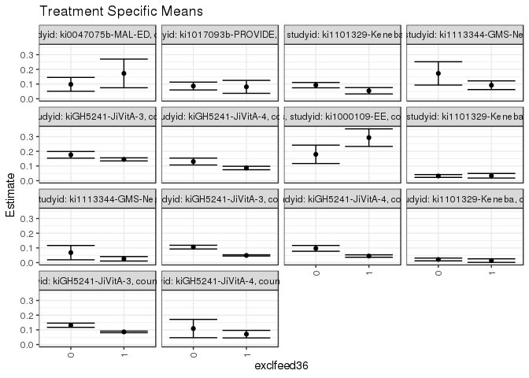

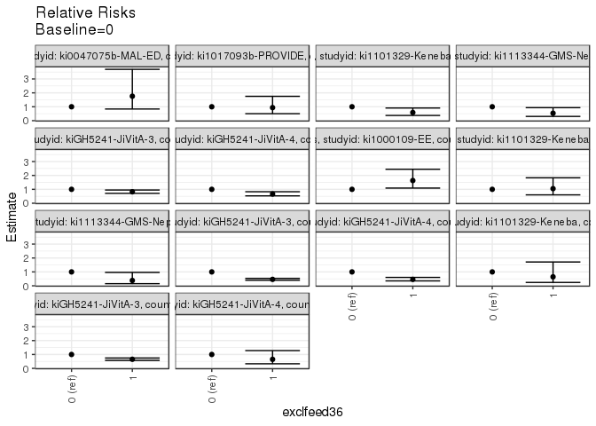

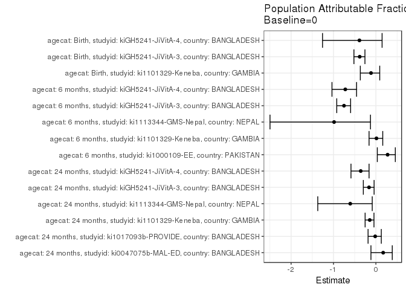

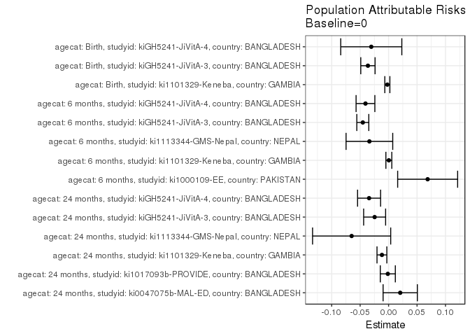

## Results Table

### Parameter: TSM

| agecat | studyid | country | intervention_level | baseline_level | estimate | ci_lower | ci_upper |
| --- | --- | --- | --- | --- | --- | --- | --- |
| Birth | ki1101329-Keneba | GAMBIA | 0 | NA | 0.0213723 | 0.0118618 | 0.0308829 |
| Birth | ki1101329-Keneba | GAMBIA | 1 | NA | 0.0137741 | 0.0017794 | 0.0257688 |
| Birth | kiGH5241-JiVitA-3 | BANGLADESH | 0 | NA | 0.1314941 | 0.1170818 | 0.1459064 |
| Birth | kiGH5241-JiVitA-3 | BANGLADESH | 1 | NA | 0.0860601 | 0.0806103 | 0.0915098 |
| Birth | kiGH5241-JiVitA-4 | BANGLADESH | 0 | NA | 0.1088435 | 0.0466294 | 0.1710577 |
| Birth | kiGH5241-JiVitA-4 | BANGLADESH | 1 | NA | 0.0706897 | 0.0451392 | 0.0962401 |
| 6 months | ki1000109-EE | PAKISTAN | 0 | NA | 0.1793103 | 0.1167861 | 0.2418346 |
| 6 months | ki1000109-EE | PAKISTAN | 1 | NA | 0.2927928 | 0.2328527 | 0.3527329 |
| 6 months | ki1101329-Keneba | GAMBIA | 0 | NA | 0.0319564 | 0.0223295 | 0.0415832 |
| 6 months | ki1101329-Keneba | GAMBIA | 1 | NA | 0.0335306 | 0.0178566 | 0.0492046 |
| 6 months | ki1113344-GMS-Nepal | NEPAL | 0 | NA | 0.0679612 | 0.0193104 | 0.1166120 |
| 6 months | ki1113344-GMS-Nepal | NEPAL | 1 | NA | 0.0260047 | 0.0108239 | 0.0411856 |
| 6 months | kiGH5241-JiVitA-3 | BANGLADESH | 0 | NA | 0.1055762 | 0.0929136 | 0.1182388 |
| 6 months | kiGH5241-JiVitA-3 | BANGLADESH | 1 | NA | 0.0488535 | 0.0447987 | 0.0529083 |
| 6 months | kiGH5241-JiVitA-4 | BANGLADESH | 0 | NA | 0.0969828 | 0.0772665 | 0.1166991 |
| 6 months | kiGH5241-JiVitA-4 | BANGLADESH | 1 | NA | 0.0447117 | 0.0364813 | 0.0529421 |
| 24 months | ki0047075b-MAL-ED | BANGLADESH | 0 | NA | 0.0980392 | 0.0508082 | 0.1452703 |
| 24 months | ki0047075b-MAL-ED | BANGLADESH | 1 | NA | 0.1724138 | 0.0749691 | 0.2698585 |
| 24 months | ki1017093b-PROVIDE | BANGLADESH | 0 | NA | 0.0864486 | 0.0598016 | 0.1130956 |
| 24 months | ki1017093b-PROVIDE | BANGLADESH | 1 | NA | 0.0810811 | 0.0370669 | 0.1250953 |
| 24 months | ki1101329-Keneba | GAMBIA | 0 | NA | 0.0927835 | 0.0745190 | 0.1110481 |
| 24 months | ki1101329-Keneba | GAMBIA | 1 | NA | 0.0542453 | 0.0326782 | 0.0758124 |
| 24 months | ki1113344-GMS-Nepal | NEPAL | 0 | NA | 0.1724138 | 0.0929521 | 0.2518755 |
| 24 months | ki1113344-GMS-Nepal | NEPAL | 1 | NA | 0.0921409 | 0.0625984 | 0.1216834 |
| 24 months | kiGH5241-JiVitA-3 | BANGLADESH | 0 | NA | 0.1758865 | 0.1532022 | 0.1985709 |
| 24 months | kiGH5241-JiVitA-3 | BANGLADESH | 1 | NA | 0.1448041 | 0.1342734 | 0.1553347 |
| 24 months | kiGH5241-JiVitA-4 | BANGLADESH | 0 | NA | 0.1302378 | 0.1068606 | 0.1536151 |
| 24 months | kiGH5241-JiVitA-4 | BANGLADESH | 1 | NA | 0.0863057 | 0.0745567 | 0.0980548 |

### Parameter: E(Y)

| agecat | studyid | country | intervention_level | baseline_level | estimate | ci_lower | ci_upper |
| --- | --- | --- | --- | --- | --- | --- | --- |
| Birth | ki1101329-Keneba | GAMBIA | NA | NA | 0.0191693 | 0.0115710 | 0.0267677 |
| Birth | kiGH5241-JiVitA-3 | BANGLADESH | NA | NA | 0.0951527 | 0.0900508 | 0.1002546 |
| Birth | kiGH5241-JiVitA-4 | BANGLADESH | NA | NA | 0.0784044 | 0.0544827 | 0.1023261 |
| 6 months | ki1000109-EE | PAKISTAN | NA | NA | 0.2479564 | 0.2037162 | 0.2921966 |
| 6 months | ki1101329-Keneba | GAMBIA | NA | NA | 0.0324022 | 0.0241972 | 0.0406072 |
| 6 months | ki1113344-GMS-Nepal | NEPAL | NA | NA | 0.0342205 | 0.0186698 | 0.0497713 |
| 6 months | kiGH5241-JiVitA-3 | BANGLADESH | NA | NA | 0.0602617 | 0.0561000 | 0.0644233 |
| 6 months | kiGH5241-JiVitA-4 | BANGLADESH | NA | NA | 0.0563414 | 0.0484727 | 0.0642101 |
| 24 months | ki0047075b-MAL-ED | BANGLADESH | NA | NA | 0.1184834 | 0.0747732 | 0.1621936 |
| 24 months | ki1017093b-PROVIDE | BANGLADESH | NA | NA | 0.0850694 | 0.0622663 | 0.1078726 |
| 24 months | ki1101329-Keneba | GAMBIA | NA | NA | 0.0810617 | 0.0667291 | 0.0953942 |
| 24 months | ki1113344-GMS-Nepal | NEPAL | NA | NA | 0.1074561 | 0.0790002 | 0.1359121 |
| 24 months | kiGH5241-JiVitA-3 | BANGLADESH | NA | NA | 0.1513522 | 0.1415495 | 0.1611548 |
| 24 months | kiGH5241-JiVitA-4 | BANGLADESH | NA | NA | 0.0959483 | 0.0853397 | 0.1065568 |

### Parameter: RR

| agecat | studyid | country | intervention_level | baseline_level | estimate | ci_lower | ci_upper |
| --- | --- | --- | --- | --- | --- | --- | --- |
| Birth | ki1101329-Keneba | GAMBIA | 0 | 0 | 1.0000000 | 1.0000000 | 1.0000000 |
| Birth | ki1101329-Keneba | GAMBIA | 1 | 0 | 0.6444831 | 0.2423845 | 1.7136347 |
| Birth | kiGH5241-JiVitA-3 | BANGLADESH | 0 | 0 | 1.0000000 | 1.0000000 | 1.0000000 |
| Birth | kiGH5241-JiVitA-3 | BANGLADESH | 1 | 0 | 0.6544786 | 0.5748652 | 0.7451176 |
| Birth | kiGH5241-JiVitA-4 | BANGLADESH | 0 | 0 | 1.0000000 | 1.0000000 | 1.0000000 |
| Birth | kiGH5241-JiVitA-4 | BANGLADESH | 1 | 0 | 0.6494612 | 0.3298393 | 1.2788041 |
| 6 months | ki1000109-EE | PAKISTAN | 0 | 0 | 1.0000000 | 1.0000000 | 1.0000000 |
| 6 months | ki1000109-EE | PAKISTAN | 1 | 0 | 1.6328829 | 1.0898063 | 2.4465875 |
| 6 months | ki1101329-Keneba | GAMBIA | 0 | 0 | 1.0000000 | 1.0000000 | 1.0000000 |
| 6 months | ki1101329-Keneba | GAMBIA | 1 | 0 | 1.0492616 | 0.6016806 | 1.8297911 |
| 6 months | ki1113344-GMS-Nepal | NEPAL | 0 | 0 | 1.0000000 | 1.0000000 | 1.0000000 |
| 6 months | ki1113344-GMS-Nepal | NEPAL | 1 | 0 | 0.3826410 | 0.1519244 | 0.9637304 |
| 6 months | kiGH5241-JiVitA-3 | BANGLADESH | 0 | 0 | 1.0000000 | 1.0000000 | 1.0000000 |
| 6 months | kiGH5241-JiVitA-3 | BANGLADESH | 1 | 0 | 0.4627324 | 0.4009137 | 0.5340832 |
| 6 months | kiGH5241-JiVitA-4 | BANGLADESH | 0 | 0 | 1.0000000 | 1.0000000 | 1.0000000 |
| 6 months | kiGH5241-JiVitA-4 | BANGLADESH | 1 | 0 | 0.4610272 | 0.3520964 | 0.6036588 |
| 24 months | ki0047075b-MAL-ED | BANGLADESH | 0 | 0 | 1.0000000 | 1.0000000 | 1.0000000 |
| 24 months | ki0047075b-MAL-ED | BANGLADESH | 1 | 0 | 1.7586206 | 0.8368484 | 3.6957071 |
| 24 months | ki1017093b-PROVIDE | BANGLADESH | 0 | 0 | 1.0000000 | 1.0000000 | 1.0000000 |
| 24 months | ki1017093b-PROVIDE | BANGLADESH | 1 | 0 | 0.9379109 | 0.5024033 | 1.7509375 |
| 24 months | ki1101329-Keneba | GAMBIA | 0 | 0 | 1.0000000 | 1.0000000 | 1.0000000 |
| 24 months | ki1101329-Keneba | GAMBIA | 1 | 0 | 0.5846436 | 0.3751606 | 0.9110981 |
| 24 months | ki1113344-GMS-Nepal | NEPAL | 0 | 0 | 1.0000000 | 1.0000000 | 1.0000000 |
| 24 months | ki1113344-GMS-Nepal | NEPAL | 1 | 0 | 0.5344173 | 0.3048268 | 0.9369318 |
| 24 months | kiGH5241-JiVitA-3 | BANGLADESH | 0 | 0 | 1.0000000 | 1.0000000 | 1.0000000 |
| 24 months | kiGH5241-JiVitA-3 | BANGLADESH | 1 | 0 | 0.8232813 | 0.7127713 | 0.9509251 |
| 24 months | kiGH5241-JiVitA-4 | BANGLADESH | 0 | 0 | 1.0000000 | 1.0000000 | 1.0000000 |
| 24 months | kiGH5241-JiVitA-4 | BANGLADESH | 1 | 0 | 0.6626779 | 0.5306755 | 0.8275152 |

### Parameter: PAR

| agecat | studyid | country | intervention_level | baseline_level | estimate | ci_lower | ci_upper |
| --- | --- | --- | --- | --- | --- | --- | --- |
| Birth | ki1101329-Keneba | GAMBIA | 0 | NA | -0.0022030 | -0.0066453 | 0.0022393 |
| Birth | kiGH5241-JiVitA-3 | BANGLADESH | 0 | NA | -0.0363414 | -0.0489007 | -0.0237820 |
| Birth | kiGH5241-JiVitA-4 | BANGLADESH | 0 | NA | -0.0304391 | -0.0841190 | 0.0232407 |
| 6 months | ki1000109-EE | PAKISTAN | 0 | NA | 0.0686461 | 0.0159450 | 0.1213471 |
| 6 months | ki1101329-Keneba | GAMBIA | 0 | NA | 0.0004459 | -0.0047642 | 0.0056560 |
| 6 months | ki1113344-GMS-Nepal | NEPAL | 0 | NA | -0.0337406 | -0.0747500 | 0.0072687 |
| 6 months | kiGH5241-JiVitA-3 | BANGLADESH | 0 | NA | -0.0453145 | -0.0558557 | -0.0347734 |
| 6 months | kiGH5241-JiVitA-4 | BANGLADESH | 0 | NA | -0.0406414 | -0.0571352 | -0.0241475 |
| 24 months | ki0047075b-MAL-ED | BANGLADESH | 0 | NA | 0.0204442 | -0.0096590 | 0.0505474 |
| 24 months | ki1017093b-PROVIDE | BANGLADESH | 0 | NA | -0.0013792 | -0.0146009 | 0.0118426 |
| 24 months | ki1101329-Keneba | GAMBIA | 0 | NA | -0.0117218 | -0.0203682 | -0.0030754 |
| 24 months | ki1113344-GMS-Nepal | NEPAL | 0 | NA | -0.0649577 | -0.1336202 | 0.0037049 |
| 24 months | kiGH5241-JiVitA-3 | BANGLADESH | 0 | NA | -0.0245344 | -0.0438394 | -0.0052293 |
| 24 months | kiGH5241-JiVitA-4 | BANGLADESH | 0 | NA | -0.0342895 | -0.0545267 | -0.0140524 |

### Parameter: PAF

| agecat | studyid | country | intervention_level | baseline_level | estimate | ci_lower | ci_upper |
| --- | --- | --- | --- | --- | --- | --- | --- |
| Birth | ki1101329-Keneba | GAMBIA | 0 | NA | -0.1149231 | -0.3671976 | 0.0908018 |
| Birth | kiGH5241-JiVitA-3 | BANGLADESH | 0 | NA | -0.3819266 | -0.5179454 | -0.2580960 |
| Birth | kiGH5241-JiVitA-4 | BANGLADESH | 0 | NA | -0.3882325 | -1.2585093 | 0.1466985 |
| 6 months | ki1000109-EE | PAKISTAN | 0 | NA | 0.2768473 | 0.0338221 | 0.4587437 |
| 6 months | ki1101329-Keneba | GAMBIA | 0 | NA | 0.0137609 | -0.1608425 | 0.1621019 |
| 6 months | ki1113344-GMS-Nepal | NEPAL | 0 | NA | -0.9859763 | -2.4978023 | -0.1275942 |
| 6 months | kiGH5241-JiVitA-3 | BANGLADESH | 0 | NA | -0.7519625 | -0.9231868 | -0.5959826 |
| 6 months | kiGH5241-JiVitA-4 | BANGLADESH | 0 | NA | -0.7213408 | -1.0357800 | -0.4554687 |
| 24 months | ki0047075b-MAL-ED | BANGLADESH | 0 | NA | 0.1725490 | -0.1163449 | 0.3866814 |
| 24 months | ki1017093b-PROVIDE | BANGLADESH | 0 | NA | -0.0162121 | -0.1840925 | 0.1278663 |
| 24 months | ki1101329-Keneba | GAMBIA | 0 | NA | -0.1446036 | -0.2536834 | -0.0450145 |
| 24 months | ki1113344-GMS-Nepal | NEPAL | 0 | NA | -0.6045039 | -1.3710031 | -0.0857990 |
| 24 months | kiGH5241-JiVitA-3 | BANGLADESH | 0 | NA | -0.1621012 | -0.2959764 | -0.0420554 |
| 24 months | kiGH5241-JiVitA-4 | BANGLADESH | 0 | NA | -0.3573751 | -0.5872565 | -0.1607872 |